# final_project

brett

April 9, 2019

Brett Waugh 9 April 2019 adult_logistic.R Looks at data about people in the United States in 1996 and makes a prediction about income. Most of script is taken from https://rpubs.com/H_Zhu/235617 with very few revisions.

Get the data from here: https://rpubs.com/H_Zhu/235617. Then read in the data.

After adding in the data, check it to make sure everything looks correct.

```r
str(adult)
```

```
## 'data.frame':    32561 obs. of  15 variables:
##  $ age           : int  39 50 38 53 28 37 49 52 31 42 ...
##  $ workclass     : Factor w/ 9 levels "?","Federal-gov",..: 8 7 5 5 5 5 5 7 5 5 ...
##  $ fnlwgt        : int  77516 83311 215646 234721 338409 284582 160187 209642 45781 159449 ...
##  $ educatoin     : Factor w/ 16 levels "10th","11th",..: 10 10 12 2 10 13 7 12 13 10 ...
##  $ educatoin_num : int  13 13 9 7 13 14 5 9 14 13 ...
##  $ marital_status: Factor w/ 7 levels "Divorced","Married-AF-spouse",..: 5 3 1 3 3 3 4 3 5 3 ...
##  $ occupation    : Factor w/ 15 levels "?","Adm-clerical",..: 2 5 7 7 11 5 9 5 11 5 ...
##  $ relationship  : Factor w/ 6 levels "Husband","Not-in-family",..: 2 1 2 1 6 6 2 1 2 1 ...
##  $ race          : Factor w/ 5 levels "Amer-Indian-Eskimo",..: 5 5 5 3 3 5 3 5 5 5 ...
##  $ sex           : Factor w/ 2 levels "Female","Male": 2 2 2 2 1 1 1 2 1 2 ...
##  $ capital_gain  : int  2174 0 0 0 0 0 0 0 14084 5178 ...
##  $ capital_loss  : int  0 0 0 0 0 0 0 0 0 0 ...
##  $ hours_per_week: int  40 13 40 40 40 40 16 45 50 40 ...
##  $ native_country: Factor w/ 42 levels "?","Cambodia",..: 40 40 40 40 6 40 24 40 40 40 ...
##  $ income        : Factor w/ 2 levels "<=50K",">50K": 1 1 1 1 1 1 1 2 2 2 ...
```

Next, we will remove some variables and create some graphs.

```r
### Three variables dropped
adult$educatoin <- NULL
adult$fnlwgt <- NULL
adult$relationship <- NULL
```

The first graph is a histogram of age by income group.

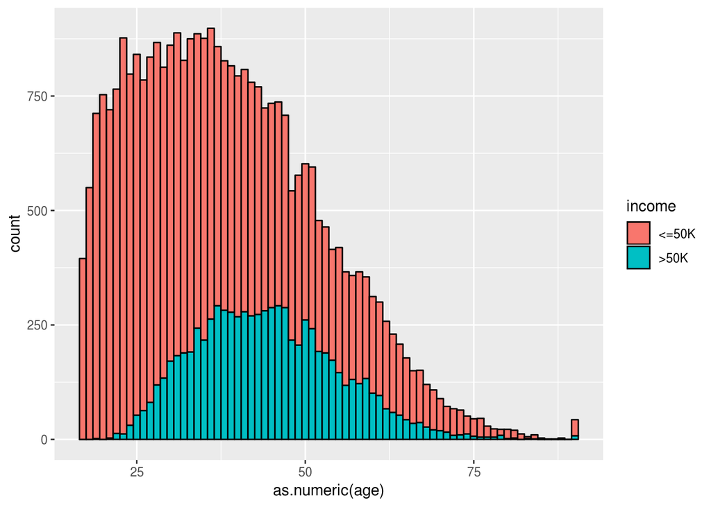

```r
# Histogram of age by income group.
ggplot(adult) + aes(x=as.numeric(age), group=income, fill=income) +
  geom_histogram(binwidth=1, color='black')
```

The next graph is a histogram of age by gender group.

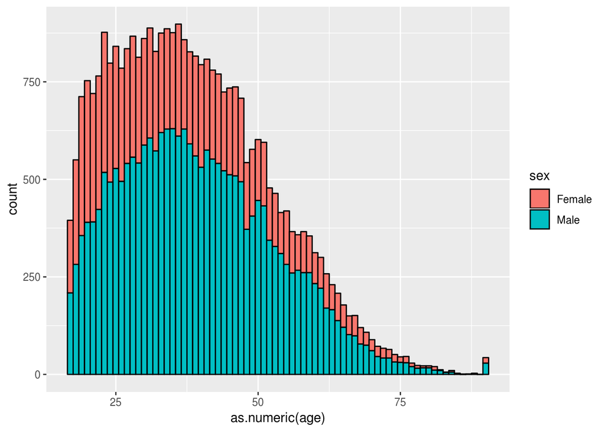

```r
# Histogram of age by gender group.
ggplot(adult) + aes(x=as.numeric(age), group=sex, fill=sex) +
  geom_histogram(binwidth=1, color='black')
```

After preparing the data more, and combining several of the fields we can create a barplot for the data.

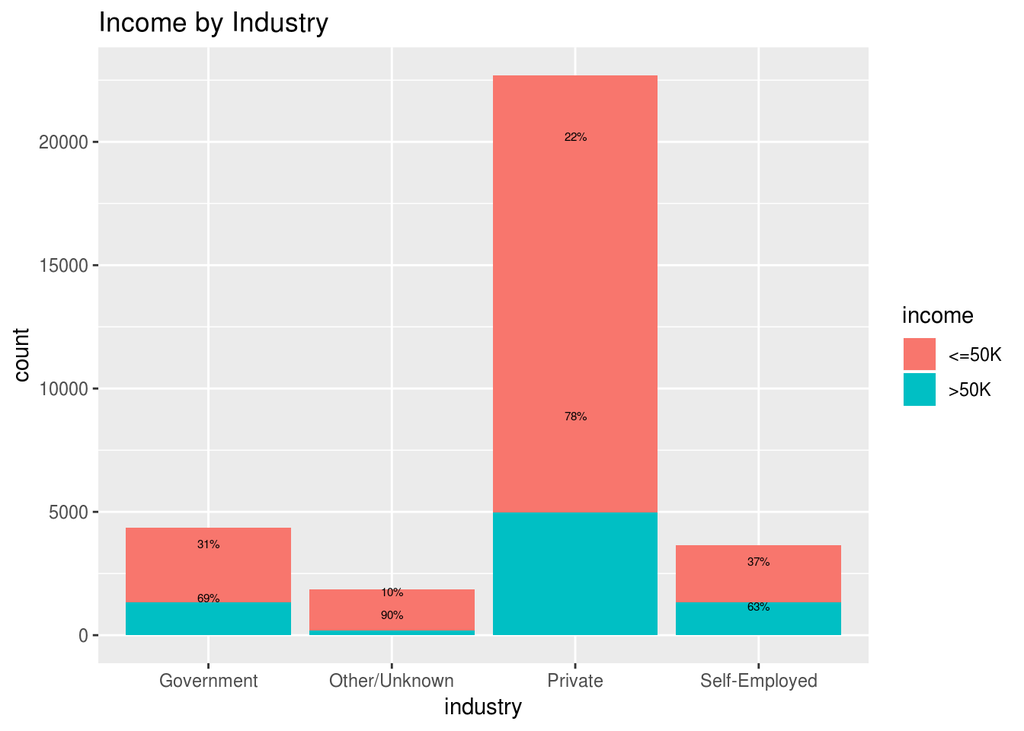

```r
# Barplot of counts by industry with in group proportions.
ggplot(df, aes(x = industry, y = count, fill = income)) +
  geom_bar(stat = "identity") +
  geom_text(aes(y = pos, label = label), size = 2) +
  ggtitle('Income by Industry')
```

After preparing an additional dataframe and calculating some values, another barplot can be created.

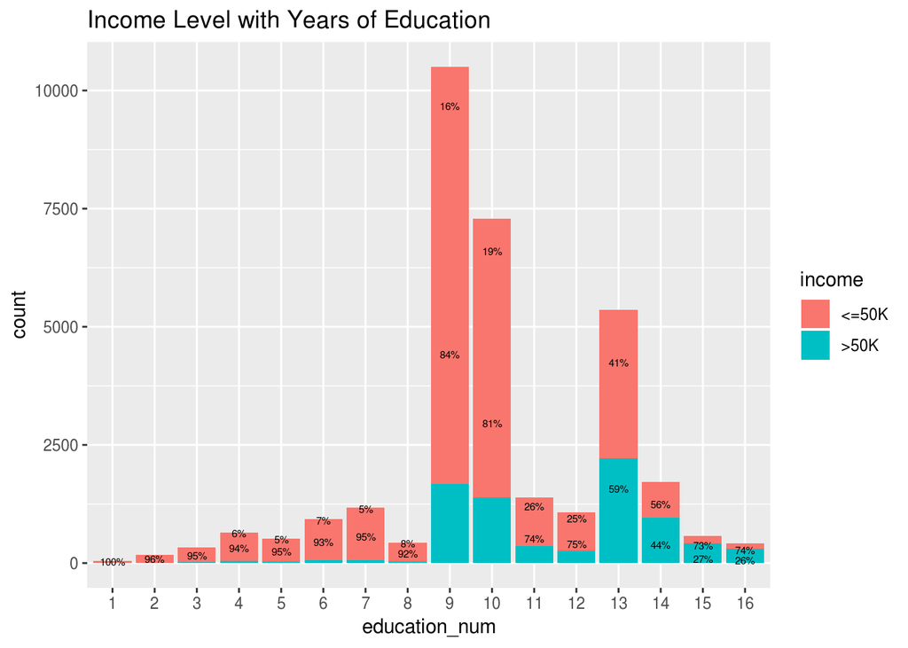

```r
# Barplot of counts by years of education with in group proportions.
ggplot(df1, aes(x = education_num, y = count, fill = income)) +
  geom_bar(stat = "identity") +
  geom_text(aes(y = pos, label = label), size = 2) +
  ggtitle('Income Level with Years of Education')
```

Immediately, it is apparent that the greatest number of people making 50k or less have nine or ten years of education. There are few individuals in the study with less than nine years of education making above 50k. The number of years with the greatest percentage above 50k are sixteen years, with fifteen years coming in a close second. From this study, 100% of those with only one year of education make 50k or less.

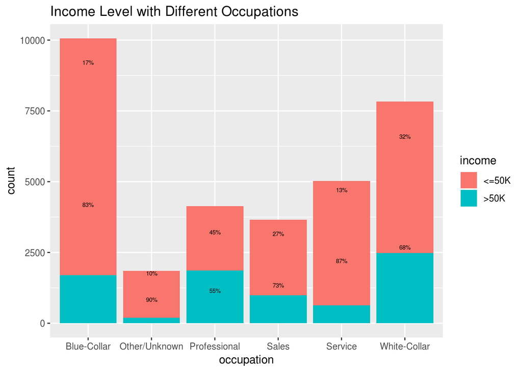

```r
# Barplot of counts by occupation with in group proportions.
ggplot(df2, aes(x = occupation, y = count, fill = income)) +
  geom_bar(stat = "identity") +
  geom_text(aes(y = pos, label = label), size = 2) +
  ggtitle('Income Level with Different Occupations')
```

Income level can very greatly depending on which field someone goes into. From this dataset, the greatest number of people making 50k or less is from the Blue-Collar occupations. The greatest number of people making more than 50k are in White-Collar occupations. While the greatest number may be in White-Collar, Professional occupations holds the greatest percentage of people making above 50k. The occupations with the greatest percentage making 50k or less is in Other/Unknown and Service.

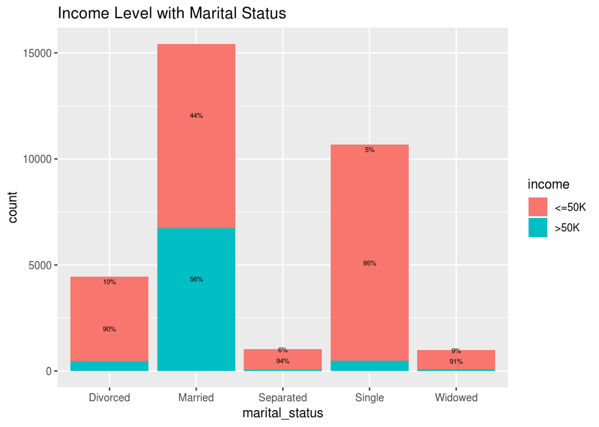

```r
# Barplot of counts by marital status with in group proportions.
ggplot(df3, aes(x = marital_status, y = count, fill = income)) +
  geom_bar(stat = "identity") +
  geom_text(aes(y = pos, label = label), size = 2) +
  ggtitle('Income Level with Marital Status')
```

Looking at the histograms for capital gains and capital losses, it is clear that very few people partake in this. Due to how few individuals partake in it, it is best to remove it from the study to not skew the results.

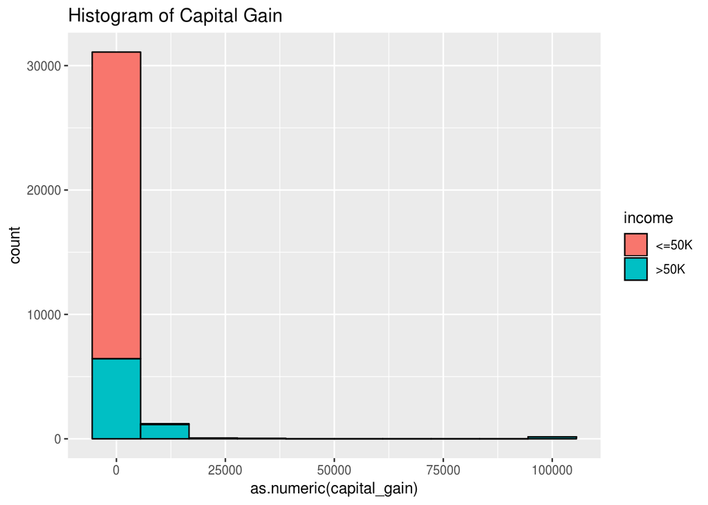

```r
# Histogram of capital_gain.
ggplot(adult) + aes(x=as.numeric(capital_gain), group=income, fill=income) +
  geom_histogram(bins=10, color='black') + ggtitle('Histogram of Capital Gain')
```

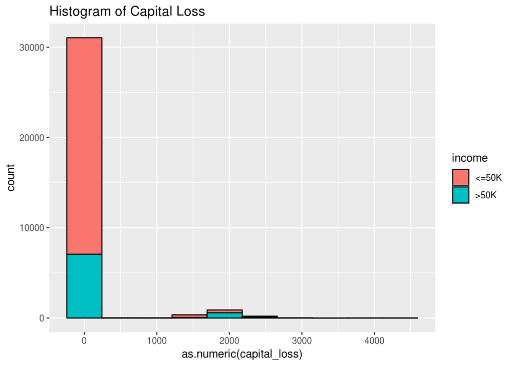

```r
# Histogram of capital_loss.
ggplot(adult) + aes(x=as.numeric(capital_loss), group=income, fill=income) +
  geom_histogram(bins=10, color='black') + ggtitle('Histogram of Capital Loss')
```

```r
# Percentage of observatiosn with no capital gain or loss.
sum(adult$capital_gain == 0)/length(adult$capital_gain)
```

```
## [1] 0.9167102
```

```r
sum(adult$capital_loss == 0)/length(adult$capital_loss)
```

```
## [1] 0.9533491
```

Native country will also be removed.

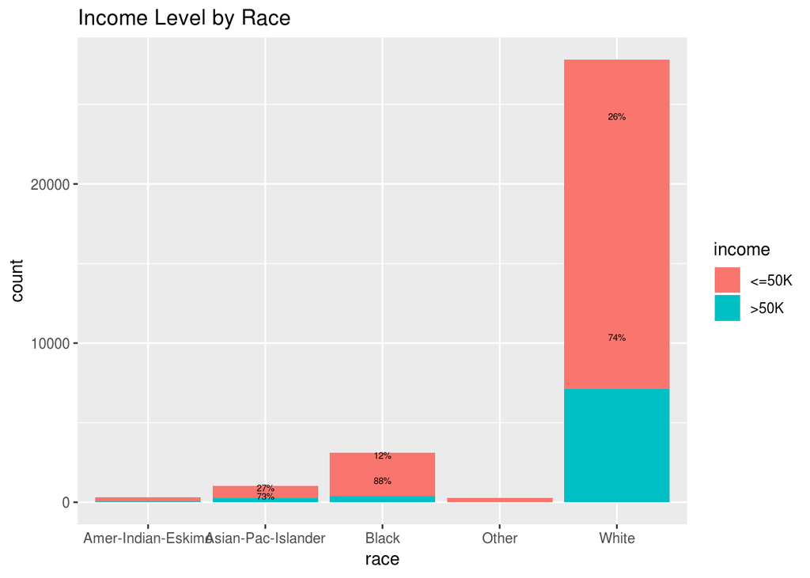

```r
# Bar plot of counts by marital status with in group proportions.
ggplot(df4, aes(x = race, y = count, fill = income)) +
  geom_bar(stat = "identity") +
  geom_text(aes(y = pos, label = label), size = 2) +
  ggtitle('Income Level by Race')
```

Looking at income distribution by race can be a tricky situation as some people can be from multple races, or are sometimes unaware of ancestry. The greatest number of people making above 50k are White, but the greatest number of people making 50k or less are also White. Amer-Indian-Eskimo, Asian-Pac-Islander, Other, and Black all have high percentages of people making 50k or less.

At this point, we only have nine remaining features to work with.

```r
summary(adult)
```

```
##       age                workclass     educatoin_num     marital_status
##  Min.   :17.00   Government   : 4351   Min.   : 1.00   Divorced : 4443
##  1st Qu.:28.00   Other/Unknown: 1857   1st Qu.: 9.00   Married  :15417
##  Median :37.00   Private      :22696   Median :10.00   Separated: 1025
##  Mean   :38.58   Self-Employed: 3657   Mean   :10.08   Single   :10683
##  3rd Qu.:48.00                         3rd Qu.:12.00   Widowed  :  993
##  Max.   :90.00                         Max.   :16.00
##          occupation                    race           sex
##  Blue-Collar  :10062   Amer-Indian-Eskimo:  311   Female:10771
##  Other/Unknown: 1852   Asian-Pac-Islander: 1039   Male  :21790
##  Professional : 4140   Black             : 3124
##  Sales        : 3650   Other             :  271
##  Service      : 5021   White             :27816
##  White-Collar : 7836
##  hours_per_week    income
##  Min.   : 1.00   <=50K:24720
##  1st Qu.:40.00   >50K : 7841
##  Median :40.00
##  Mean   :40.44
##  3rd Qu.:45.00
##  Max.   :99.00
```

The next stage in the process is creating a model. For this particular dataset, logistic regression will be used.

```r
summary(m1)
```

```
##
## Call:
## glm(formula = income ~ ., family = binomial("logit"), data = training_set)
##
## Deviance Residuals:
##     Min       1Q   Median       3Q      Max
## -2.6900  -0.5892  -0.2606  -0.0752   3.2844
##
## Coefficients:
##                          Estimate Std. Error z value Pr(>|z|)
## (Intercept)             -9.304867   0.278827 -33.371  < 2e-16 ***
## age                      0.028424   0.001632  17.413  < 2e-16 ***
## workclassOther/Unknown  -1.226062   0.812990  -1.508   0.1315
## workclassPrivate         0.065641   0.053401   1.229   0.2190
## workclassSelf-Employed  -0.143134   0.068836  -2.079   0.0376 *
## educatoin_num            0.316604   0.009367  33.799  < 2e-16 ***
## marital_statusMarried    2.009367   0.067075  29.957  < 2e-16 ***
## marital_statusSeparated -0.118183   0.162774  -0.726   0.4678
## marital_statusSingle    -0.456110   0.082510  -5.528 3.24e-08 ***
## marital_statusWidowed   -0.049819   0.153751  -0.324   0.7459
## occupationOther/Unknown  0.890005   0.811907   1.096   0.2730
## occupationProfessional   0.758835   0.067266  11.281  < 2e-16 ***
## occupationSales          0.493151   0.063295   7.791 6.63e-15 ***
## occupationService        0.156311   0.066728   2.343   0.0192 *
## occupationWhite-Collar   0.775103   0.052391  14.795  < 2e-16 ***
## raceAsian-Pac-Islander   0.127056   0.248409   0.511   0.6090
## raceBlack                0.307972   0.237403   1.297   0.1945
## raceOther               -0.466651   0.370702  -1.259   0.2081
## raceWhite                0.489306   0.227223   2.153   0.0313 *
## sexMale                  0.387568   0.051550   7.518 5.55e-14 ***
## hours_per_week           0.030626   0.001629  18.802  < 2e-16 ***
## ---
## Signif. codes:  0 '***' 0.001 '**' 0.01 '*' 0.05 '.' 0.1 ' ' 1
##
## (Dispersion parameter for binomial family taken to be 1)
##
##     Null deviance: 28685  on 26048  degrees of freedom
## Residual deviance: 19163  on 26028  degrees of freedom
## AIC: 19205
##
## Number of Fisher Scoring iterations: 6
```

```r
confint(m1)
```

```
##                               2.5 %       97.5 %
## (Intercept)             -9.86450760 -8.769848897
## age                      0.02522800  0.031627206
## workclassOther/Unknown  -2.81095155  0.353340625
## workclassPrivate        -0.03879528  0.170549950
## workclassSelf-Employed  -0.27807457 -0.008224174
## educatoin_num            0.29832991  0.335050878
## marital_statusMarried    1.87910604  2.142085777
## marital_statusSeparated -0.44670006  0.192468641
## marital_statusSingle    -0.61768425 -0.294168625
## marital_statusWidowed   -0.35840810  0.245101683
## occupationOther/Unknown -0.69042951  2.469666670
## occupationProfessional   0.62703557  0.890730836
## occupationSales          0.36894319  0.617075711
## occupationService        0.02504151  0.286644006
## occupationWhite-Collar   0.67249541  0.877875622
## raceAsian-Pac-Islander  -0.34768819  0.628341149
## raceBlack               -0.14373152  0.789261324
## raceOther               -1.20916579  0.249803089
## raceWhite                0.05890259  0.952096611
## sexMale                  0.28666433  0.488756993
## hours_per_week           0.02744120  0.033826994
```

We can see the relationships between some of the variables here. Notice some of the features with the low P Values: age, education_num, martital_StatusMarried, martitalStatusSingle, occupationProfessional, OccupationSales, occupationWhite-Collar, sexMale, and hours_per_week. These features seem to have a significant impact on determing the income of an individual.

```r
# confusion matrix
tb <- table(pred, testing_set$income)
tb
```

```
##
## pred    <=50K >50K
##   <=50K  4533  745
##   >50K    379  855
```

```r
(4533+855)/(4533+745+379+855)
```

```
## [1] 0.8273956
```

From the confusion matrix we can determine the accuracy of the model to be 0.827 or 82.7%. This is a great score for the model, because it does not suggest overfitting while maintaining a high degree of accuracy. Given information about an individual, the model should be able to accurately predict if the individual makes greater than 50k 82.7% of the time.

The second model uses a slightly different approach to the problem.

```r
otherModel
```

```
## Generalized Linear Model
##
## 26049 samples
##     8 predictors
##     2 classes: '<=50K', '>50K'
##
## No pre-processing
## Resampling: Cross-Validated (10 fold, repeated 10 times)
## Summary of sample sizes: 23444, 23445, 23444, 23444, 23445, 23444, ...
## Resampling results:
##
##   Accuracy   Kappa
##   0.8243121  0.4731953
```

While this model took a different approach to the problem, it still yielded an accuracy of 0.824 or 82.4%. Another benefit to this model is that it uses 10-fold cross validation, making it understandable to lose an additional percentage from the first model.